# Binary Search Trees

*And all this time I thought "BST" stood for some kind of sandwich* 🥪

A **Binary Search Tree (BST)** is a tree with a few additional qualities:

## Traversing a BST

With a generic tree, the order you iterate through children is undefined.

For a BST, you always iterate from `left` to `right`.

5, 3, 2, 1, 4, 7, 6, 9, 8

What is the postorder (DFS) traversal of this tree?

1, 2, 4, 3, 6, 8, 9, 7, 5

With BSTs, there is another kind of traversal available: **in-order** (a.k.a *inorder*)

You process the left child before the node before the right child.

I.E. `left`, `this`, `right`

What is the inorder traversal of our binary tree?

1, 2, 3, 4, 5, 6, 7, 8, 9

🤯

😮 🤯 🤭 🤔 😵 😶‍🌫️ 😴

## Code

```python
#include <string>
#include <iostream>
#include <sstream>
using namespace std;
```

```python
template<class T>
struct Node {
    T value;
    Node<T>* left;
    Node<T>* right;
    explicit Node(T value) : value(value), left(nullptr), right(nullptr) {}
};
```

```python
template<class T>
void _inorder_to_string(Node<T>* const& node, string const& prefix, vector<string>& lines) {
    if (node == nullptr) {
        return;
    }

    // Because this will print out top-to-bottom
    //  and we will be reading it out sideways
    //  we print right before left
    //  so the sideways text will read left-to-right

    // Print right
    _inorder_to_string(node->left, prefix + "  ", lines);

    // Print node
    stringstream ss;
    ss << prefix << node->value;
    lines.push_back(ss.str());

    // Print left
    _inorder_to_string(node->right, prefix + "  ", lines);
}


template<class T>
string inorder_to_string(Node<T>* const& node) {
    vector<string> lines;
    _inorder_to_string(node, "", lines);

    // Transpose!
    int max_len = 0;
    for (auto line : lines) {
        max_len = (max_len < line.length()) ? line.length() : max_len;
    }

    char** out = new char*[max_len];
    for (int i = 0; i < max_len; i++) {
        out[i] = new char[lines.size()];
    }

    stringstream ss;
    for (int i = 0; i < max_len; i++) {
        for (int j = 0; j < lines.size(); j++) {
            if (i < lines[j].length()) {
                ss << lines[j][i];
            } else {
                ss << ' ';
            }
        }
        ss << endl;
    }

    return ss.str();
}
```

```python
template<class T>
void print_inorder(Node<T>* const& node) {
    cout << inorder_to_string(node) << endl;
}
```

```python
Node<string>* M = new Node<string>("M");

M->left = new Node<string>("G");
M->left->left = new Node<string>("A");
M->left->right = new Node<string>("J");

M->right = new Node<string>("T");
M->right->left = new Node<string>("Q");
```

```python
print_inorder(M)
```

```
   M

 G   T

A J Q
```

## How can we tell if a value is in our BST?

Perform a depth-first-search!

- If the current node value is the search value, return true.
- If the search value is less than our current value, search the left subtree.
- If the search value is greater than our current value, search the right subtree.
- If I'm supposed to search the left or right subtree but there is no node there, return false.
- What is my base case?
- Do we progress towards the base case?
- Is the induction correct?
- What is my base case?
  - If the current node is the search value
  - If I'm supposed to recurse but there is no node to recurse onto
- Do we progress towards the base case?
  - Yes, at each step I move further down the tree.
  - At some point I'll find my value or run out of tree.
- Is the induction correct?
  - If the search value is equal to the current value I'm done.
  - Every value in the left subtree is less than the current value.
  - Every value in the right subtree is greater than the current value.
  - If the search value is greater than the current value, then if it is in the tree it will be found in the right subtree and we continue our search there.
    - Symmetric logic for the left side
  - So, if the problem isn't solved on step $k$, we progress towards a solution with step $k+1$.

```python
template<class T>
Node<T>* search_bst(Node<T>* const& node, T item) {
    // If current node is null or the value is the same, return current
    if (node == nullptr || node->value == item) {
        return node;
    }

    // Check left
    if (item < node->value) {
        return search_bst(node->left, item);
    } else {
        // Check right
        return search_bst(node->right, item);
    }
}
```

```python
auto node = search_bst(M, (string)"Z");

if (node != nullptr) {
    cout << node->value << endl;
} else {
    cout << "nullptr" << endl;
}
```

```
nullptr
```

## BST Big O

What is the Big-O for BST search?

At each step we cut out half of the search values.

How many times can I cut $n$ values in half before I run out of values?

$O(\log n)$

We've observed the following properties about BSTs:

- $O(\log n)$ search time
- Does not permit duplicate values
- Prints out contents in sorted order (using the inorder traversal)

What data structure have we seen with these qualities?

A **set**!

🤯

Sets (i.e. *ordered* sets) are implemented with a BST.

But wait, you say.

You can add and remove items from a set. How do we add to and remove from a BST?

## Adding Items to a BST

- Let the root be the current node.
- While the current node is not null:
  - If the item is equal to the current node value, return false (item not added)
  - If the item is greater than the current node value, let current = current.right
  - If the item is less than the current node value, let current == current.left
- Insert the item at the current location

What do I get when I insert 2?

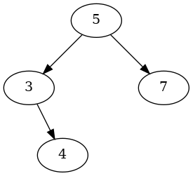

- 2 < 5, go left
- 2 < 3, go left
- No node here, add it!

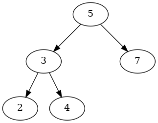

What happens when I insert 8?

- 8 > 5, go right
- 8 > 7, go right
- No node here, add it!

What happens when I insert 4?

- 4 < 5, go left
- 4 > 3, go right
- 4 == 4, return false

```python
template<class T>
bool add(Node<T>*& node, T item) {
    if (node == nullptr) {
        node = new Node<T>(item);
        return true;
    }
    if (node->value == item) {
        return false;
    }
    if (item < node->value) {
        return add(node->left, item);
    } else {
        return add(node->right, item);
    }
}
```

```python
add(M, (string)"Z")
```

[output not shown]

```python
add(M, (string)"Z")
```

```
false
```

```python
add(M, (string)"a")
```

```
true
```

```python
print_inorder(M)
```

```
   M

 G   T

A J Q Z

       a
```

### Big-O for Add

What is the big-O complexity for add?

At each iteration, I halve the size of the tree I still need to search, so $O(\log n)$

### Can I use a BST to sort and find data?

Sure!

What would the big-O complexity be for such an algorithm?

Time to add an item: $O(\log n)$

How many items to I have to add? $O(n)$

Total complexity: $O(n \log n)$

### Key Ideas

- Adding a node preserves the structure of the BST
- Adding a node takes $O(\log n)$ time

## Removing from a BST

If I want to remove 4, what do I do?

- Find 4, delete it, and set 3->right to `nullptr`

What if I want to remove 7?

- Find 7, delete it, and have 5 point to 8.

What if I want to delete 3?

Which node should take its place?

What if I want to delete 5?

Which node should take its place?

- When a node has no children, it's easy: just delete the node.
- When a node has only one child, it's easy: just replace the node with the child.
- When a node has two children (and possibly decendents!), we need a little more decision making.

### Inorder Predecessor

When removing a node with two children, we want to replace the node with the **inorder predecessor**.

I.E the node that would come immediately before the removed node in an inorder traversal.

**The inorder predecessor is the largest node in the left subtree.**

What is the inorder predecessor for 1?

**0**

What is the inorder predecessor for 3?

**2**

What is the inorder predecessor for 6?

**5**

What is the inorder predecessor for 15?

**14**

What is the inorder predecessor for 10?

**8**

```python
template<class T>
Node<T>* inorder_predecessor(Node<T>* const& node) {
    // Pass in the node, not the left child
    Node<T>* iop = node->left;
    while (iop->right != nullptr) {
        iop = iop->right;
    }
    return iop;
}
```

```python
print_inorder(M)
```

```
   M

 G   T

A J Q Z

       a
```

```python
auto node = inorder_predecessor(M);
cout << node->value << endl;
```

```
J
```

## Removing from a BST

```
bool remove(node, value):
    if node is null, return false

    if node->value == value:
        if node->left == null:
            node = node->right
        else if node->right == null:
            node = node->left
        else:
            iop = get_inorder_predecessor(node)
            node->value = iop->value
            remove(node->left, iop->value)
        return true

    else if value < node->value:
        return remove(node->left, value)

    else:
        return remove(node->right, value)
```

What will the tree look like after removing **17**?

[figure not shown]

What will the tree look like after removing **6**?

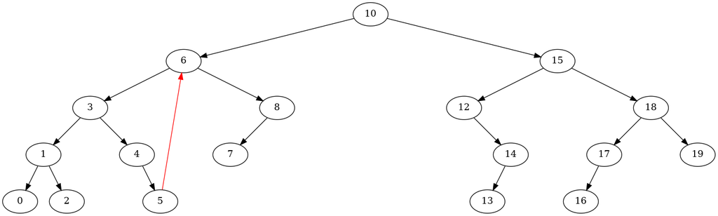

[figure not shown]

What will the tree look like after removing **15**?

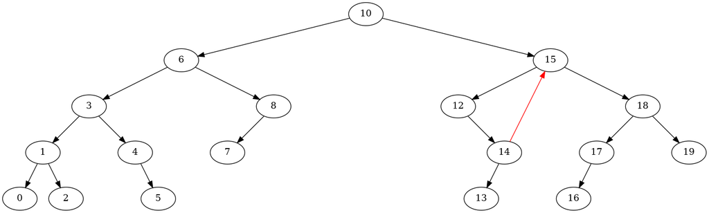

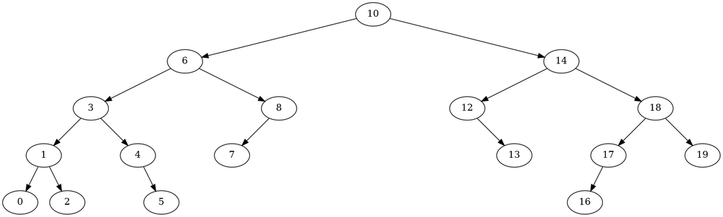

### Big-O complexity of remove

What is the time complexity of the remove function?

At each iteration I do constant work.

I have at most $\log n$ iterations (I will have to potentially search down to the lowest leaf during the search for an inorder predecessor).

$O(\log n)$

### Key Ideas

- When removing a node:
  - If the node has no children, just remove it
  - If the node has only one child, just replace it with the child
  - If the node has two children, replace its value with the value of its inorder predecessor and remove the inorder predecessor

## Pathologic BST

What kind of tree do I get when I add 1, 2, 3, 4, 5, 6, 7, 8, 9, in that order?

```python
auto tree = new Node<int>(1);
for (int i = 1; i <= 9; i++) {
    add(tree, i);
}
print_inorder(tree)
```

```
1

 2

  3

   4

    5

     6

      7

       8

        9
```

What is the big-O search complexity for this tree?

$O(n)$!

### Key Ideas

- The $O(\log n)$ lookup depends on the tree having a balanced structure.

## Key Ideas for a BST

- $O(\log n)$ complexity for search, add, and remove
  - But only if the tree stays balanced!
- BST is the underlying structure used to implement `set` and `map`